# 05_RForest_LightGBM_XGBoost

## 5. **Aplicación de Modelos**

En este notebook se desarrollan los siguientes modelos con la aplicación de sus métricas:

1. Random Forest
2. Light GBM
3. XGBoost

### Librerías

```python
from sklearn.ensemble import RandomForestClassifier
from xgboost import XGBClassifier
from lightgbm import LGBMClassifier
from sklearn.metrics import classification_report
from funciones_metricas import *

import matplotlib.pyplot as plt
import numpy as np
import pandas as pd
import seaborn as sns
import scikitplot as skp
import lightgbm as lgb
import xgboost as xgb

import warnings
warnings.filterwarnings('ignore')
```

### Carga de datos

```python
path_folder = "./"
x_train_1 = pd.read_csv(path_folder +"Xtrain1_data.csv", low_memory=False)
x_val = pd.read_csv(path_folder +"Xval_data.csv", low_memory=False)

y_train_1 = pd.read_csv(path_folder +"ytrain1_data.csv", low_memory=False)
y_val = pd.read_csv(path_folder +"yval_data.csv", low_memory=False)
```

### 4. Random Forest

Se trata de un modelo que ajusta una serie de clasificadores de árboles de decisión en varias submuestras del dataset, haciendo uso de promedios para mejorar la precisión y controlar el overfitting.

- Robustez frente al sobreajuste (Overfitting): Random Forest está diseñado para mitigar el sobreajuste, que es cuando un modelo se adapta demasiado a los datos de entrenamiento y no generaliza bien a nuevos datos. Al construir múltiples árboles de decisión y promediar sus predicciones, Random Forest reduce la tendencia a sobreajustarse a patrones específicos de los datos de entrenamiento.

#### 4.1 Inspección de datos

```python
x_train = x_train_1
x_train
```

|  | cluster | payment_type_AA | payment_type_AB | payment_type_AC | payment_type_AD | payment_type_AE | employment_status_CA | employment_status_CB | employment_status_CC | employment_status_CD | ... | has_other_cards | proposed_credit_limit | foreign_request | session_length_in_minutes | keep_alive_session | device_distinct_emails_8w | month | address_months_total | email_similarity_binary | income_times_age |
| --- | --- | --- | --- | --- | --- | --- | --- | --- | --- | --- | --- | --- | --- | --- | --- | --- | --- | --- | --- | --- | --- |
| 0 | 2 | -0.590132 | 1.304404 | -0.580936 | -0.367381 | -0.01681 | 0.607801 | -0.40024 | -0.198245 | -0.165085 | ... | -0.535176 | -0.647751 | -0.161164 | -0.447130 | 0.855854 | -0.100844 | -0.583487 | 1.359557 | 0.315382 | 0.825027 |
| 1 | 3 | 1.694535 | -0.766633 | -0.580936 | -0.367381 | -0.01681 | 0.607801 | -0.40024 | -0.198245 | -0.165085 | ... | -0.535176 | -0.647751 | -0.161164 | -0.369173 | 0.855854 | -0.100844 | 0.321531 | -0.952983 | 0.315382 | 1.603001 |
| 2 | 3 | 1.694535 | -0.766633 | -0.580936 | -0.367381 | -0.01681 | 0.607801 | -0.40024 | -0.198245 | -0.165085 | ... | -0.535176 | -0.647751 | -0.161164 | -0.317346 | 0.855854 | 5.437772 | -1.488504 | -0.666778 | 0.315382 | 0.825027 |
| 3 | 8 | -0.590132 | 1.304404 | -0.580936 | -0.367381 | -0.01681 | -1.645275 | -0.40024 | -0.198245 | -0.165085 | ... | -0.535176 | -0.647751 | -0.161164 | -0.204811 | -1.168423 | -0.100844 | -1.488504 | 0.420803 | -3.170756 | -1.119908 |
| 4 | 9 | 1.694535 | -0.766633 | -0.580936 | -0.367381 | -0.01681 | 0.607801 | -0.40024 | -0.198245 | -0.165085 | ... | -0.535176 | -0.647751 | -0.161164 | -0.503445 | 0.855854 | -0.100844 | 1.679057 | -0.506502 | -3.170756 | 0.358243 |
| ... | ... | ... | ... | ... | ... | ... | ... | ... | ... | ... | ... | ... | ... | ... | ... | ... | ... | ... | ... | ... | ... |
| 14205 | 1 | 1.694535 | -0.766633 | -0.580936 | -0.367381 | -0.01681 | 0.607801 | -0.40024 | -0.198245 | -0.165085 | ... | -0.535176 | 2.019515 | -0.161164 | -0.344464 | -1.168423 | -0.100844 | 0.321531 | -0.414917 | 0.315382 | 0.591635 |
| 14206 | 1 | -0.590132 | -0.766633 | 1.721361 | -0.367381 | -0.01681 | 0.607801 | -0.40024 | -0.198245 | -0.165085 | ... | -0.535176 | -0.647751 | -0.161164 | -0.542852 | -1.168423 | 5.437772 | -1.035995 | 0.111701 | 0.315382 | 0.047053 |
| 14207 | 5 | -0.590132 | -0.766633 | 1.721361 | -0.367381 | -0.01681 | 0.607801 | -0.40024 | -0.198245 | -0.165085 | ... | -0.535176 | -0.647751 | -0.161164 | 0.153688 | 0.855854 | -0.100844 | -1.488504 | -0.517951 | 0.315382 | 0.980622 |
| 14208 | 1 | -0.590132 | -0.766633 | -0.580936 | 2.721967 | -0.01681 | 0.607801 | -0.40024 | -0.198245 | -0.165085 | ... | -0.535176 | 2.019515 | -0.161164 | 0.694800 | -1.168423 | -0.100844 | 0.774039 | -0.517951 | 0.315382 | 1.291812 |
| 14209 | 9 | -0.590132 | 1.304404 | -0.580936 | -0.367381 | -0.01681 | 0.607801 | -0.40024 | -0.198245 | -0.165085 | ... | -0.535176 | 2.019515 | 6.204863 | 0.064824 | -1.168423 | 5.437772 | -1.488504 | 0.832939 | -3.170756 | -0.264136 |

14210 rows × 50 columns

```python
y_train = y_train_1
y_train
```

|  | fraud_bool |
| --- | --- |
| 0 | 0 |
| 1 | 0 |
| 2 | 0 |
| 3 | 0 |
| 4 | 0 |
| ... | ... |
| 14205 | 1 |
| 14206 | 1 |
| 14207 | 1 |
| 14208 | 1 |
| 14209 | 1 |

14210 rows × 1 columns

#### 4.2 Modelado

```python
# Entrenamiento
modelo_randomf = RandomForestClassifier(n_estimators=10)
modelo_randomf = modelo_randomf.fit(x_train, y_train)
modelo_randomf
```

```
RandomForestClassifier(n_estimators=10)
```

**Parámetros**

- El único parámetro empleado para entrenar el modelo es el **n_estimators**: cantidad de árboles en el bosque. Existen otros parámetros que se encuentran de forma predeterminada en el modelo:
1. criterio:"gini" = predeterminado
2. max_depth: None = predeterminado. De esta forma, los nodos se expanden hasta que todas las hojas sean puras o hasta que todas las hojas contengan menos de min_samples_split muestras
3. min_samples_split: 2 = predeterminado. El número mínimo de muestras necesarias para dividir un nodo interno.
4. min_samples_leaf: 1 = predeterminado. El número mínimo de muestras necesarias para estar en un nodo de hoja.
5. Existen otros parámetros predeterminados como:min_weight_fraction_leaf=0.0, max_features='sqrt', max_leaf_nodes=None, min_impurity_decrease=0.0, bootstrap=True, oob_score=False, n_jobs=None, random_state=None, verbose=0, warm_start=False, class_weight=None, ccp_alpha=0.0, max_samples=None.

Fuente: https://scikit-learn.org/stable/modules/generated/sklearn.ensemble.RandomForestClassifier.html

```python
# Predicción
y_pred = modelo_randomf.predict(x_train)
y_pred
```

```
array([0, 0, 0, ..., 1, 1, 1], dtype=int64)
```

#### 4.3 Evaluación del modelo

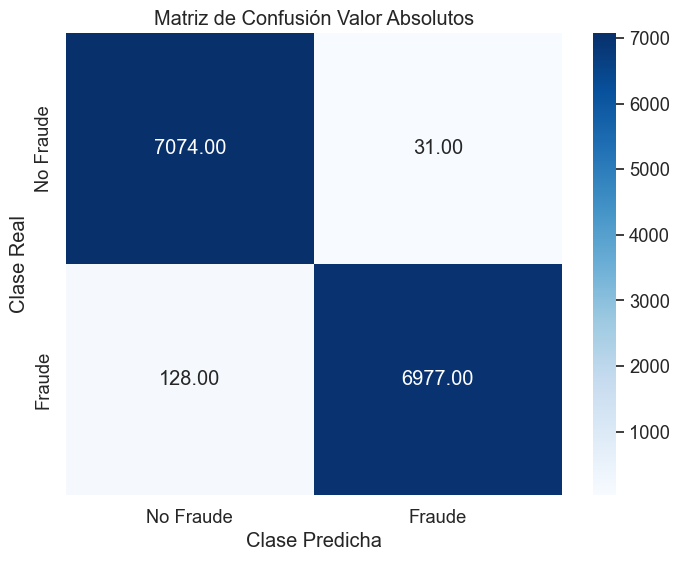

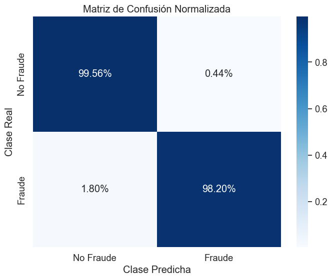

```python
plot_confusion_matrices(y_train, y_pred)
```

En la matriz de confusión se puede apreciar una clara mejoría con respecto a resultados anteriores.

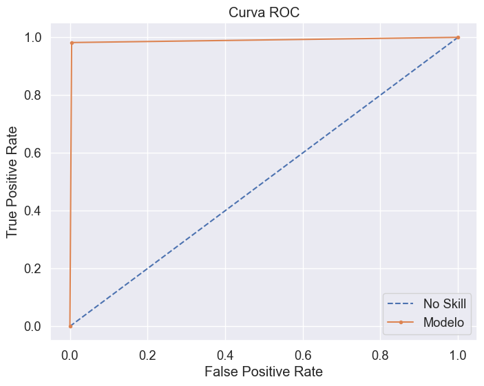

```python
plot_roc_curve(y_train, y_pred)
```

La curva ROC muestra unos resultados muy positivos porque indica que el modelo se ha entrenado correctamente, aproximándose al mejor de sus entrenamientos. Aún así, habrá que comparar con el test para cerciorarnos de que no haya sobreajuste.

```python
calcular_accuracy_score(y_train, y_pred)
```

```
0.9888106966924701
```

El accuracy del modelo es muy elevado, superando el 98% de aciertos.

```
Best Threshold=1.000, F1-Score=0.989
```

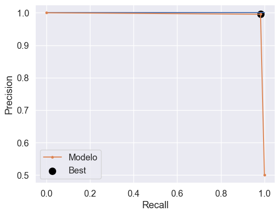

```
F-Score: 0.98873
```

```
(1, 0.9887337915397151)
```

```python
evaluar_modelo_precision_recall(y_train, y_pred)
```

Se puede apreciar como el F-score es muy elevado (F1-Score=0.989), alcanzando casi el 1.0.

```python
print(classification_report(y_train, y_pred))
```

```
              precision    recall  f1-score   support

           0       0.98      1.00      0.99      7105
           1       1.00      0.98      0.99      7105

    accuracy                           0.99     14210
   macro avg       0.99      0.99      0.99     14210
weighted avg       0.99      0.99      0.99     14210
```

### 5. Light GBM

El modelo Light Gradient Boosting Machine es un modelo basado en el algoritmo de aumento de gradiente (gradient boosting). Es una implementación eficiente y que puede enriquecer la predicción de nuestro modelo por los siguientes motivos:

1. Regularización y control de sobreajuste: LightGBM incluye parámetros de regularización que permiten controlar el sobreajuste durante el entrenamiento. Esto es esencial para evitar que el modelo se ajuste demasiado a los datos de entrenamiento y no generalice bien a nuevos datos.
2. Manejo de datos desequilibrados: LightGBM tiene opciones incorporadas para manejar conjuntos de datos desequilibrados, lo que es útil en problemas de clasificación donde las clases tienen frecuencias muy diferentes.

#### 5.1 Inspección de datos

```python
train_data = lgb.Dataset(x_train, label=y_train)
valid_data = lgb.Dataset(x_val, label=y_val, reference=train_data)
```

#### 5.2 Modelado

```python
# Parámetros
params = {
    'objective': 'binary',
    'metric': 'binary_error',
    'boosting_type': 'gbdt',
    'num_leaves': 31,
    'learning_rate': 0.05,
    'feature_fraction': 0.9
}
```

**Parámetros**

1. objective: 'binary' al tratarse de una clasificación binaria, especifica la función de pérdida que el modelo tratará de optimizar.
2. metric: 'binary_error' mide la tasa de error en la clasificación binaria.
3. boosting_type:'gbdt' es el método de Gradient Boosting Decision Tree, que es uno de los métodos más comunes de impulso.
4. num_leaves: 31 es el número máximo de hojas en un árbol. Un valor más alto puede mejorar la precisión, pero también puede aumentar el riesgo de sobreajuste.
5. learning_rate: con un valor de 0.05, se controla la tasa de aprendizaje del modelo. Al ser un valor más bajo requiere de un mayor número de iteraciones, pero esto puede mejorar la generalización.
6. feature_fraction: 0.9 es el número elegido para indicar la fracción de características que se utilizarán en cada iteración. Introduce aleatoriedad, reduciendo al mismo tiempo el sobreajuste.

Fuente: https://github.com/microsoft/LightGBM/blob/master/docs/Parameters.rst

```python
# Entrenamiento
num_boost_round = 1000  # Número total de iteraciones
model_lightgbm = lgb.train(params, train_data, num_boost_round=num_boost_round, valid_sets=[train_data, valid_data])
```

```
[LightGBM] [Info] Number of positive: 7105, number of negative: 7105
[LightGBM] [Info] Auto-choosing row-wise multi-threading, the overhead of testing was 0.003062 seconds.
You can set `force_row_wise=true` to remove the overhead.
And if memory is not enough, you can set `force_col_wise=true`.
[LightGBM] [Info] Total Bins 2781
[LightGBM] [Info] Number of data points in the train set: 14210, number of used features: 46
[LightGBM] [Info] [binary:BoostFromScore]: pavg=0.500000 -> initscore=0.000000
```

```python
# Prediccion
y_pred = model_lightgbm.predict(x_val, num_iteration=model_lightgbm.best_iteration)
```

```python
# Probabilidades transformadas en etiquetas binarias
umbral = 0.5  # Puedes ajustar este umbral según sea necesario
y_pred_binario = (y_pred > umbral).astype(int)
```

#### Evaluación del modelo

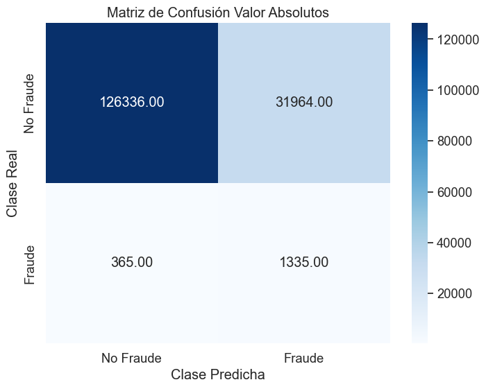

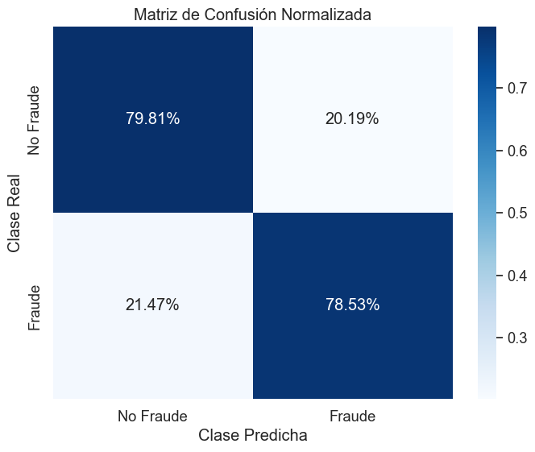

```python
plot_confusion_matrices(y_val, y_pred_binario)
```

En la matriz de confusión se puede ver un buen resultado de las predicciones:

```python
calcular_accuracy_score(y_val, y_pred_binario)
```

```
0.79794375
```

Un accuracy cercano al 80% de resultados acertados. Esto es buen resultado que, si bien es superado por el Random Forest, puede ser útil para entrenar con los datos de test.

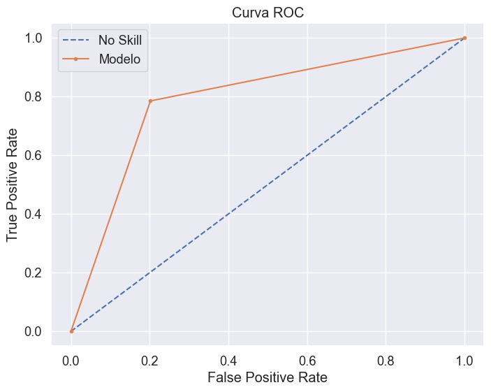

```python
plot_roc_curve(y_val, y_pred_binario)
```

La curva ROC se muestra similar a la de regresión logística. Más cercano al 80% de tasa de verdaderos positivos.

```
Best Threshold=1.000, F1-Score=0.076
```

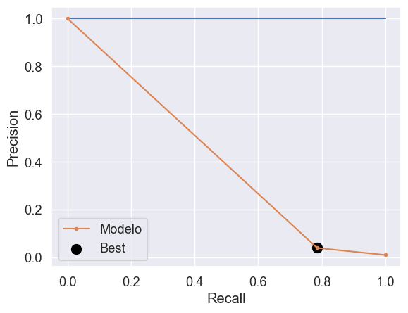

```
F-Score: 0.07629
```

```
(1, 0.07628789393982685)
```

```python
evaluar_modelo_precision_recall(y_val, y_pred_binario)
```

El F-score = 0.076 no es muy elevado por lo que es necesario prestar especial atención a la precisión.

```python
print(classification_report(y_val, y_pred_binario))
```

```
              precision    recall  f1-score   support

           0       1.00      0.80      0.89    158300
           1       0.04      0.79      0.08      1700

    accuracy                           0.80    160000
   macro avg       0.52      0.79      0.48    160000
weighted avg       0.99      0.80      0.88    160000
```

## 6. XGBoost

Se trata de un algoritmo de aprendizaje supervisado que se puede utilizar para problemas de clasificación, en este caso binaria. Combina múltiples modelos de árboles de decisión para formar un modelo más fuerte a través del boosting, con el fin de mejorar el rendimiento de forma iterativa.

Fuente: https://xgboost.readthedocs.io/en/stable/

#### 6.1 Inspección de datos

```python
train_data = xgb.DMatrix(x_train, label=y_train)
valid_data = xgb.DMatrix(x_val, label=y_val)
```

#### 6.2 Modelado

```python
# Parámetros
params = {
    'objective': 'binary:logistic',
    'eval_metric': 'logloss',
    'max_depth': 3,
    'learning_rate': 0.1,
    'n_estimators': 100
}
```

**Parámetros**

1. 'objective': 'binary:logistic'. Indica que el modelo está optimizando la log-verosimilitud para la clasificación binaria.
2. 'eval_metric': 'logloss': Se refiere a la pérdida logarítmica, que es comúnmente utilizada en problemas de clasificación binaria para medir el rendimiento.
3. 'max_depth': 3: este parámetro controla la profundidad máxima de cada árbol en el conjunto. Limitar la profundidad ayuda a prevenir el sobreajuste y mejora la generalización del modelo.
4. 'learning_rate': 0.1: la tasa de aprendizaje controla la contribución de cada árbol al modelo general. Un valor más bajo requiere más árboles para lograr un rendimiento similar, pero puede mejorar la generalización y reducir el sobreajuste.
5. 'n_estimators': 100. Se trata de un valor comúnmente utilizado como punto de partida para especificar el número de árboles-estimadores en el conjunto.

```python
# Entrenamiento
modelo_xgboost = xgb.train(params, train_data, num_boost_round=params['n_estimators'])
```

```python
# Prediccion y transformación a valores binarios
y_pred_prob = modelo_xgboost.predict(valid_data)
y_pred = [1 if pred > 0.5 else 0 for pred in y_pred_prob]
```

#### 6.3 Evaluación del modelo

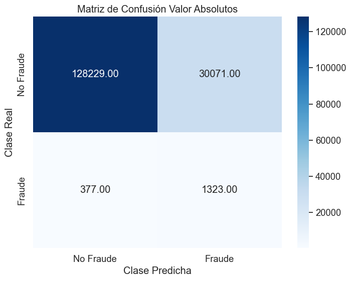

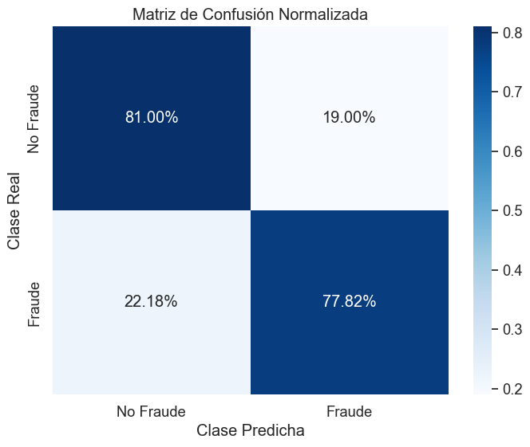

```python
plot_confusion_matrices(y_val, y_pred)
```

En la matriz de confusión se puede ver un buen resultado de las predicciones:

```python
calcular_accuracy_score(y_val, y_pred)
```

```
0.8097
```

El accuracy se sitúa en el 80%, similar a otros modelos como el LIGHT GBM.

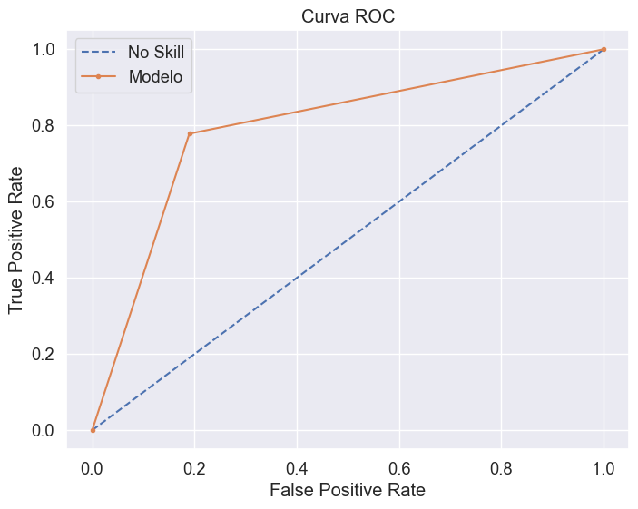

```python
plot_roc_curve(y_val, y_pred)
```

La Curva ROC es similar a otros modelos como el LIGHT GBM o la regresión logística, situándose en una menor tasa de falsos positivos.

```
Best Threshold=1.000, F1-Score=0.080
```

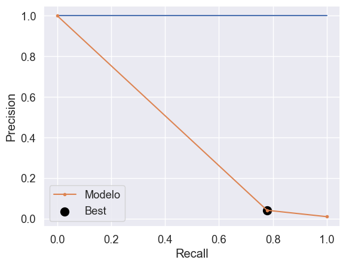

```
F-Score: 0.07995
```

```
(1, 0.07995407022420983)
```

```python
evaluar_modelo_precision_recall(y_val, y_pred)
```

Al obtener un F-Score reducido, F-Score=0.080, se podría afirmar que para balancear entre precisión y recall es necesario prestar especial atención a la precisión, puesto que el valor está por debajo de 1.

```python
print(classification_report(y_val, y_pred))
```

```
              precision    recall  f1-score   support

           0       1.00      0.81      0.89    158300
           1       0.04      0.78      0.08      1700

    accuracy                           0.81    160000
   macro avg       0.52      0.79      0.49    160000
weighted avg       0.99      0.81      0.89    160000
```